# 432 Class 12

Thomas E. Love, Ph.D.

2024-02-22

## Today’s Agenda

- Using `caret` to help with k-fold cross validation
- Building a Table One

## Today’s R Setup

```r
knitr::opts_chunk$set(comment = NA)

library(janitor)
library(broom)
library(caret)
library(tableone)
library(tidyverse)

theme_set(theme_bw())
```

# K-Fold Cross-Validation

## Tiny Data Set for a Linear Model

The `maleptsd` file contains information on PTSD (post traumatic stress disorder) symptoms following childbirth for 64 fathers<sup>1</sup>.

```r
maleptsd <- read_csv("c12/data/maleptsd.csv", show_col_types = FALSE) |>
  clean_names() |>
  mutate(ptsd = log(ptsd_raw + 1)) |>
  relocate(ptsd, .after = id)
```

`ptsd`, the response, measures PTSD symptoms, and we have 10 candidate predictors for that response.

[^1]: Source: Ayers et al. 2007 *J Reproductive and Infant Psychology*. The data are described in more detail in Wright DB and London K (2009) *Modern Regression Techniques Using R* Sage Publications.

## The maleptsd data

```r
maleptsd
```

```
# A tibble: 64 × 13
   id     ptsd over2 over3 over5  bond posit   neg contr   sup  cons   aff
   <chr> <dbl> <dbl> <dbl> <dbl> <dbl> <dbl> <dbl> <dbl> <dbl> <dbl> <dbl>
 1 P01   0         0     0    10    26  48.8   4.6  58.8  18.8    65    10
 2 P02   3.95      3     3    10    28  49.9  10.9  65    13.8    60    12
 3 P03   2.20     10    10    10    22  22.5  34.2  59.5  10      65    12
 4 P04   1.39      0     0    10    22  40.3  20.2  38.7  16      50    11
 5 P05   1.61      8     7     9    22  43    32.1  41.8  14.2    51     9
 6 P06   2.08      1     1     9    23  44.9  19.3  59.1  17.3    61    12
 7 P07   2.08      0     0    10    24  39.3  25    45    14.3    49    10
 8 P08   1.10      8    10     8    26  23.5  36.6  25.1   1.7    55    12
 9 P09   3.33      9    10     4    18  11.5  38.9  24    10.3    14     0
10 P10   0.693     5     0     9    19  35.6  25.1  29.9   2.3    48    10
# ℹ 54 more rows
# ℹ 1 more variable: ptsd_raw <dbl>
```

## More predictors than we can handle

Only 64 observations and 10 potential predictors.

- Suppose we decide to try 5 of the predictors, specifically `over3`, `bond`, `neg`, `sup` and `aff`.

```r
m1 <- lm(ptsd ~ over3 + bond + neg + sup + aff, data = maleptsd)

glance(m1) |> select(r2 = r.squared, adjr2 = adj.r.squared, AIC, BIC)
```

```
# A tibble: 1 × 4
     r2 adjr2   AIC   BIC
  <dbl> <dbl> <dbl> <dbl>
1 0.260 0.197  206.  221.
```

- Note nominal $R^2$ of 0.260.

## Set up five-fold cross-validation

Use the **caret** package’s `trainControl()` function

```r
set.seed(4322024)
ctrl <- trainControl(method = "cv", number = 5)
```

Next, we train our model on those five folds:

```r
ptsd_mod <- train(ptsd ~ over3 + bond + neg + sup + aff,
                  data = maleptsd, method = "lm",
                  trControl = ctrl)
```

Results on next slide.

## `ptsd_mod` results

```r
ptsd_mod
```

```
Linear Regression

64 samples
 5 predictor

No pre-processing
Resampling: Cross-Validated (5 fold)
Summary of sample sizes: 52, 51, 50, 51, 52
Resampling results:

  RMSE      Rsquared   MAE
  1.239869  0.1428023  1.072237

Tuning parameter 'intercept' was held constant at a value of TRUE
```

- Compare this to the nominal $R^2$ we saw earlier of 0.2604.

## A New Model with Two Predictors

Perhaps we can justify a two-predictor model.

```r
m2 <- lm(ptsd ~ aff + neg, data = maleptsd)

glance(m2) |> select(r2 = r.squared, adjr2 = adj.r.squared, AIC, BIC)
```

```
# A tibble: 1 × 4
     r2 adjr2   AIC   BIC
  <dbl> <dbl> <dbl> <dbl>
1 0.203 0.176  205.  213.
```

## Train new model on same 5 folds

```r
ptsd_mod2 <- train(ptsd ~ neg + aff, data = maleptsd,
                   method = "lm", trControl = ctrl)

ptsd_mod2
```

```
Linear Regression

64 samples
 2 predictor

No pre-processing
Resampling: Cross-Validated (5 fold)
Summary of sample sizes: 52, 52, 50, 51, 51
Resampling results:

  RMSE      Rsquared   MAE
  1.154213  0.2030121  0.9863553

Tuning parameter 'intercept' was held constant at a value of TRUE
```

## Model Summaries within each fold

```r
ptsd_mod2$resample
```

```
       RMSE   Rsquared       MAE Resample
1 1.1536878 0.18020759 0.9206545    Fold1
2 1.2300847 0.02992272 1.0488347    Fold2
3 0.9475468 0.21652976 0.8473368    Fold3
4 1.3963512 0.03472384 1.1842472    Fold4
5 1.0433949 0.55367662 0.9307033    Fold5
```

## Final Model from cross-validation

```r
ptsd_mod2$finalModel
```

```
Call:
lm(formula = .outcome ~ ., data = dat)

Coefficients:
(Intercept)          neg          aff
   -0.23311      0.04191      0.10648
```

```r
glance(ptsd_mod2$finalModel) |>
  select(r2 = r.squared, adjr2 = adj.r.squared, AIC, BIC)
```

```
# A tibble: 1 × 4
     r2 adjr2   AIC   BIC
  <dbl> <dbl> <dbl> <dbl>
1 0.203 0.176  205.  213.
```

## Tidied Coefficients from C-V model 2

```r
tidy(ptsd_mod2$finalModel, conf.int = TRUE,
     conf.level = 0.90)
```

```
# A tibble: 3 × 7
  term        estimate std.error statistic p.value conf.low conf.high
  <chr>          <dbl>     <dbl>     <dbl>   <dbl>    <dbl>     <dbl>
1 (Intercept)  -0.233     0.527     -0.443 0.660    -1.11      0.646
2 neg           0.0419    0.0125     3.34  0.00143   0.0210    0.0629
3 aff           0.106     0.0473     2.25  0.0280    0.0275    0.185
```

### “Variable Importance”

```r
varImp(ptsd_mod2)
```

```
lm variable importance

    Overall
neg     100
aff       0
```

Linear Fit: based on absolute value of t statistic for each parameter

## Residual Plots (1) for final model

```r
par(mfrow = c(1,2)); plot(ptsd_mod2$finalModel, which = c(1:2))
```

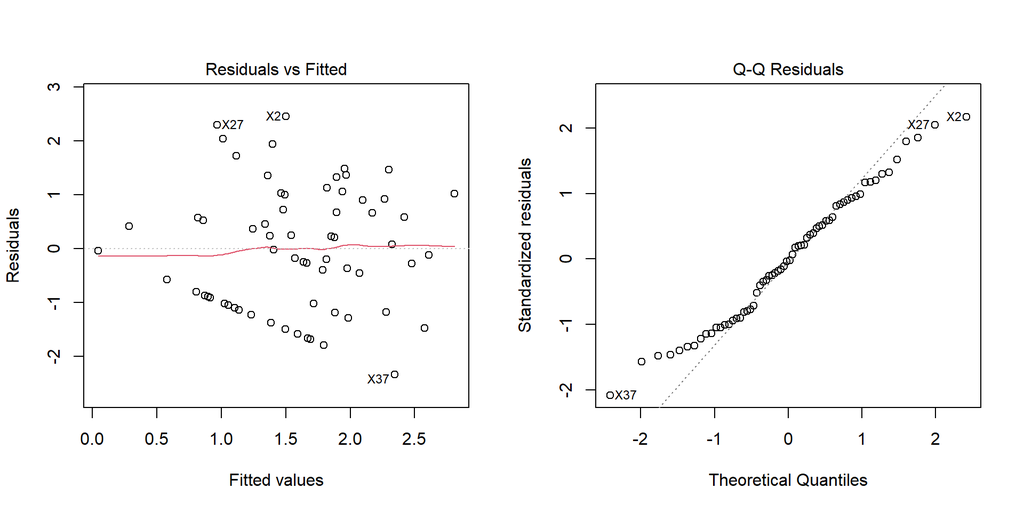

## Residual Plots (2) for final model

```r
par(mfrow = c(1,2)); plot(ptsd_mod2$finalModel, which = c(3,5))
```

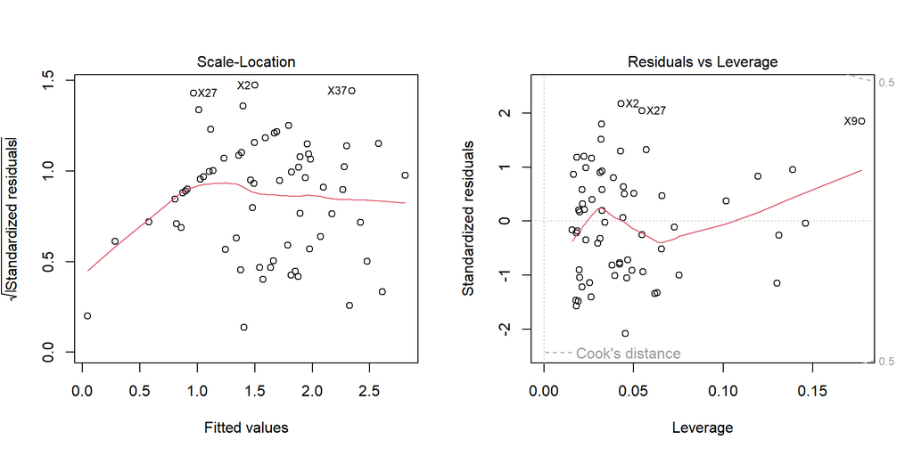

## More on K-fold Cross-Validation

Linear regression example in section 16.5 of our Course Notes.

- More on caret package at https://topepo.github.io/caret/ although that’s older now, and the tidymodels approach will allow us to do a lot of the same things later this term.

Can you do something similar to this with a `glm()` fit in logistic regression?

- Yes, definitely. See the next few slides and also [Section 48 here](https://rforhr.com/kfold.html#estimate_kfold_logistic).

## K-Fold Cross-Validation for a Logistic Regression Fit using `glm()`

Suppose we look at a new outcome: is `ptsd` > 0?

```r
maleptsd <- maleptsd |>
  mutate(gg0 = factor(ifelse(ptsd == 0, "No", "Yes"))) |>
  relocate(gg0)

maleptsd |> tabyl(gg0)
```

```
 gg0  n percent
  No 18 0.28125
 Yes 46 0.71875
```

Suppose we want to fit a logistic regression model to predict `gg0` on the basis of `aff` and `neg` (the same two predictors as we used for `ptsd`)

## Set up five-fold cross-validation

```r
set.seed(43220241)
ctrl <- trainControl(method = "cv", number = 5)

gg0_mod <- train(gg0 ~ neg + aff, data = maleptsd,
                 method = "glm", family = binomial,
                 trControl = ctrl)
gg0_mod
```

```
Generalized Linear Model

64 samples
 2 predictor
 2 classes: 'No', 'Yes'

No pre-processing
Resampling: Cross-Validated (5 fold)
Summary of sample sizes: 52, 51, 51, 51, 51
Resampling results:

  Accuracy   Kappa
  0.7666667  0.3345462
```

## Interpreting these summaries

- Model accuracy shows the proportion of observations where the model classified the subject correctly.
  - Here, our model correctly classifies 76.7% of subjects
- Kappa measures classification accuracy but accounts for the baseline probabilities of the Yes/No groups.
  - Common Thresholds (from Landis and Koch 1977) are:
    - 0.81 - 1.0 Almost perfect, 0.61 - 0.80 Substantial, 0.41 - 0.60 Moderate, 0.21 - 0.40 Fair, 0.01 - 0.2 Slight
  - Here, our model does a fair job, with $\kappa = 0.33$.

## Confusion Matrix

```r
predictions <- predict(gg0_mod)

confusionMatrix(data = predictions, maleptsd$gg0)
```

```
Confusion Matrix and Statistics

          Reference
Prediction No Yes
       No   6   5
       Yes 12  41

               Accuracy : 0.7344
                 95% CI : (0.6091, 0.837)
    No Information Rate : 0.7188
    P-Value [Acc > NIR] : 0.4528

                  Kappa : 0.2548

 Mcnemar's Test P-Value : 0.1456

            Sensitivity : 0.33333
            Specificity : 0.89130
         Pos Pred Value : 0.54545
         Neg Pred Value : 0.77358
             Prevalence : 0.28125
         Detection Rate : 0.09375
   Detection Prevalence : 0.17188
      Balanced Accuracy : 0.61232

       'Positive' Class : No
```

## Use `summary()` to obtain final model

```r
summary(gg0_mod)
```

```
Call:
NULL

Coefficients:
            Estimate Std. Error z value Pr(>|z|)
(Intercept) -2.49291    1.21035  -2.060   0.0394 *
neg          0.08451    0.02990   2.827   0.0047 **
aff          0.21229    0.10864   1.954   0.0507 .
---
Signif. codes:  0 '***' 0.001 '**' 0.01 '*' 0.05 '.' 0.1 ' ' 1

(Dispersion parameter for binomial family taken to be 1)

    Null deviance: 76.049  on 63  degrees of freedom
Residual deviance: 63.255  on 61  degrees of freedom
AIC: 69.255

Number of Fisher Scoring iterations: 4
```

## `glance()` and `tidy()` after c/v

```r
glance(gg0_mod$finalModel)
```

```
# A tibble: 1 × 8
  null.deviance df.null logLik   AIC   BIC deviance df.residual  nobs
          <dbl>   <int>  <dbl> <dbl> <dbl>    <dbl>       <int> <int>
1          76.0      63  -31.6  69.3  75.7     63.3          61    64
```

```r
tidy(gg0_mod$finalModel, exponentiate = TRUE,
     conf.int = TRUE, conf.level = 0.90)
```

```
# A tibble: 3 × 7
  term        estimate std.error statistic p.value conf.low conf.high
  <chr>          <dbl>     <dbl>     <dbl>   <dbl>    <dbl>     <dbl>
1 (Intercept)   0.0827    1.21       -2.06 0.0394   0.00978     0.544
2 neg           1.09      0.0299      2.83 0.00470  1.04        1.15
3 aff           1.24      0.109       1.95 0.0507   1.04        1.49
```

## Variable Importance in model classification

```r
varImp(gg0_mod)
```

```
glm variable importance

    Overall
neg     100
aff       0
```

So the information from `neg` is what’s making the difference here.

# Building a Table One

## An Original Clinical Investigation

[figure not shown]

[Link to Source](https://jamanetwork.com/journals/jamanetworkopen/fullarticle/2720923)

## Part of Bradley et al.’s Table 1

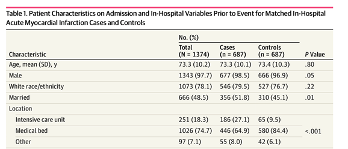

## Table Creation Instructions, JAMA: [linked here](https://jama.jamanetwork.com/data/ifora-forms/jama/tablecreationinst.pdf)

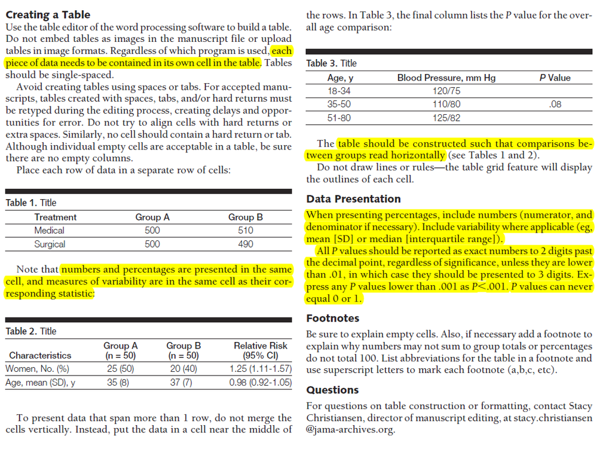

## A Data Set

The `bradley.csv` data set is simulated, but consists of 1,374 observations (687 Cases and 687 Controls) containing:

- a subject identification code, in `subject`
- `status` (case or control)
- age (in years)
- sex (Male or Female)
- race/ethnicity (white or non-white)
- married (1 = yes or 0 = no)
- location (ICU, bed, other)

The `bradley.csv` data closely match the summary statistics provided in Table 1 of the Bradley et al. article. Our job is to recreate that part of Table 1, as best as we can.

## The `bradley.csv` data (first 5 rows)

- The `bradley_sim.md` file on our web site shows you how I simulated the data.

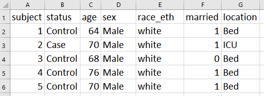

## To “Live” Coding

On our web site (Data and Code + Class 12 materials)

- In the `data` folder:
  - `bradley.csv` data file
- `bradley_table1.qmd` Quarto script
- `bradley_table1.md` Results of running Quarto
- `bradley_table1_result.csv` is the table generated by that Quarto script

# To The “Live Code”

## Opening `bradley_table1_result.csv` in Excel

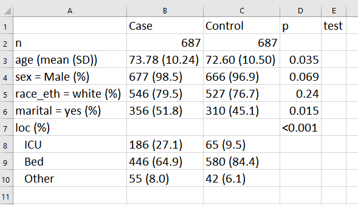

## Learning More About Table 1

Chapter 18 of the Course Notes covers two larger examples, and more details, like…

- specifying factors, and re-ordering them when necessary
- using non-normal summaries or exact categorical tests
- dealing with warning messages and with missing data
- producing Table 1 in R so you can cut and paste it into Excel or Word

## Next Time

- Thinking About Power: Retrospective Design
- Robust Linear Models

Good luck on the Quiz!

432 Class 12 | 2024-02-22 | https://thomaselove.github.io/432-2024/